# Iris explorer

Lisa

2023-05-12

# 1 Preface

- Scope and goals
- Prerequisites
- Procedure

# 2 The Challenges

## 2.1 Read the data set

**The data set is stored in `raw_data/irisData.csv`.**

- Read the data and store it in a (preliminary) data structure that seems appropriate to you.
- Which data structure do you chose and why?

**Hint**

- `csv` is a format for text files.
- The first row of the data file contains the column headings.
- Rows are separated by a line break`\n`.
- Columns are separated by a comma `,`.

```r
# Read data and store it as "flowers" ----

# Set working directory to the parent directory of "raw_data"
# ...

data_path <- file.path("raw_data", "irisData.csv")
if (file.exists(data_path)) {
  # read the data from the folder and store it as "flowers"
  flowers <- read.csv(data_path,
                      header = TRUE)
  # read.csv stores the data as data.frame, see ?data.frame
} else {
  # hint: iris is a built-in data set that comes with your R installation
  data("iris") # load
  flowers <- iris # name it "flowers"
}
```

## 2.2 Assemble a first-aid kit for coding

In coding, you will regularly encounter errors – whether you are a beginner, an advanced user or a professional. One of the most essential skills in programming (and life) is to learn how to help yourself and how to ask others for help.

**Make a list of approaches how to deal with coding errors.**

- Find at least 4 ways how to help yourself or get help from others.
- Organize your list. For instance, what could be a reasonable order for trying the different approaches? Or can you group the items by problem type?
- Present your results with a code or a notebook entry.

```r
# Some ideas

# - Read the task description again and make sure to understand the problem at hand.
# - Read the error/ warning message carefully. To which line does it refer? Which type of error/ warning is it? What could have gone wrong in that line (or the lines near it)?
# - Look up the documentation. Which parameters does the function/ class etc. need? Which types of data are expected? What is it supposed to return?
# - Look up examples of correct usage. Try to run the example and adjust it for your own program.
# - Test your code after modifying it.
# - Take a break.
# - Search a forum for threads that describe similar problems. Could your problem have the same origin? Which solutions have been discussed there?
# - Create an own thread in which you describe your problem, your goal and attach your code to get help from other users. What exactly would you need to tell other people so that they can understand and help?
```

## 2.3 The iris flower

**Do an online research.**

- What is an iris flower? How does it look like? Where do they grow?
- Find pictures of the species *iris setosa*, *versicolor*, and *virginica*.
- Compare the species of irises: What do they have in common, which features distinguish them?

**Hint**

- It’s fine to use a search engine.
- It’s fine to study Wikipedia articles.

## 2.4 Strucure of the data

**Get an overview over the data.**

- How many rows are there, how many columns?
- What could the columns mean? What could the rows indicate?
- Which kind of values do you find in each column? Which data type would you use to represent them adequately?

```r
cat("columns:", ncol(flowers), end = "\n")
## columns: 5
colnames(flowers)
```

```
## [1] "Sepal.Length" "Sepal.Width"  "Petal.Length" "Petal.Width"  "Species"
```

```r
# lengths and widths of the sepals and petals [numeric values in cm]
# name of iris species [name]

cat("rows:", nrow(flowers), end = "\n")
## rows: 150
# number of flowers for which sepals and petal were measured

cat("structure of data set:", end = "\n")
## structure of data set:
str(flowers)
```

```
## 'data.frame':    150 obs. of  5 variables:
##  $ Sepal.Length: num  5.1 4.9 4.7 4.6 5 5.4 4.6 5 4.4 4.9 ...
##  $ Sepal.Width : num  3.5 3 3.2 3.1 3.6 3.9 3.4 3.4 2.9 3.1 ...
##  $ Petal.Length: num  1.4 1.4 1.3 1.5 1.4 1.7 1.4 1.5 1.4 1.5 ...
##  $ Petal.Width : num  0.2 0.2 0.2 0.2 0.2 0.4 0.3 0.2 0.2 0.1 ...
##  $ Species     : chr  "setosa" "setosa" "setosa" "setosa" ...
```

## 2.5 Prepare the data

**Data types**

- If necessary, convert the data columns to the adequate data type.
- How could you summarize and visualize the data per column? Collect ideas.

```r
# Species
unique(flowers$Species) # There are 3 species
```

```
## [1] "setosa"     "versicolor" "virginica"
```

```r
flowers$Species <- as.factor(flowers$Species) # Make sure column is a factor (in case we read it from plain text file)
```

## 2.6 Scales of measurement

- Find out about the different scales of measurement.
- Which scale of measurement do you think describes the data in each column best?
- Do your currently used data types reflect the measurement scale? Explain why/ why not and convert the data if necessary.

## 2.7 Numeric summary

- Make a summary for each numeric column (irrespective of species). Which kind of measure summarizes the data adequately? Explain your choices.
- What does the summary reveal about the data?

```r
# Description per column
lapply(flowers, function(x) { cbind(summary(x)) })
```

```
## $Sepal.Length
##             [,1]
## Min.    4.300000
## 1st Qu. 5.100000
## Median  5.800000
## Mean    5.843333
## 3rd Qu. 6.400000
## Max.    7.900000
##
## $Sepal.Width
##             [,1]
## Min.    2.000000
## 1st Qu. 2.800000
## Median  3.000000
## Mean    3.057333
## 3rd Qu. 3.300000
## Max.    4.400000
##
## $Petal.Length
##          [,1]
## Min.    1.000
## 1st Qu. 1.600
## Median  4.350
## Mean    3.758
## 3rd Qu. 5.100
## Max.    6.900
##
## $Petal.Width
##             [,1]
## Min.    0.100000
## 1st Qu. 0.300000
## Median  1.300000
## Mean    1.199333
## 3rd Qu. 1.800000
## Max.    2.500000
##
## $Species
##            [,1]
## setosa       50
## versicolor   50
## virginica    50
```

```r
# For the species column
table(flowers$Species) # Same number of flowers for each species
```

```
##
##     setosa versicolor  virginica
##         50         50         50
```

## 2.8 Correlations

- What is a correlation? Which values can a correlation coefficient take and what does it mean?
- Find out about common methods of computing a correlation.
- Calculate the Pearson-correlations for the petals and sepals.

```r
print(cor(flowers[1:4]), digits = 2)
```

```
##              Sepal.Length Sepal.Width Petal.Length Petal.Width
## Sepal.Length         1.00       -0.12         0.87        0.82
## Sepal.Width         -0.12        1.00        -0.43       -0.37
## Petal.Length         0.87       -0.43         1.00        0.96
## Petal.Width          0.82       -0.37         0.96        1.00
```

## 2.9 Boxplots and histograms

- Make a boxplot or a histogram for each numeric column (irrespective of species).
- How do you interpret the boxplots?/ histograms?
- What do the plots reveal about the petals and sepals in general?

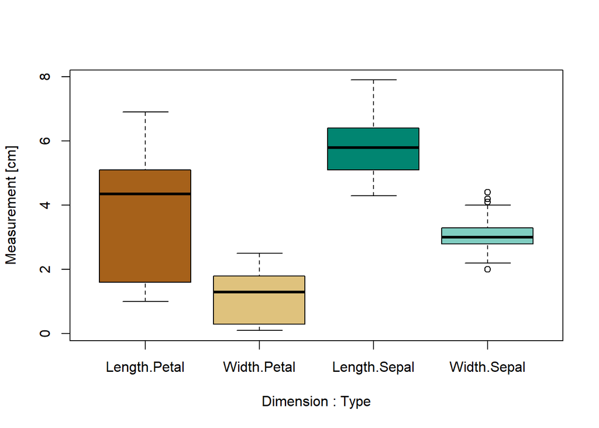

Figure 2.1: Boxplots of the sepal and petal measurements.

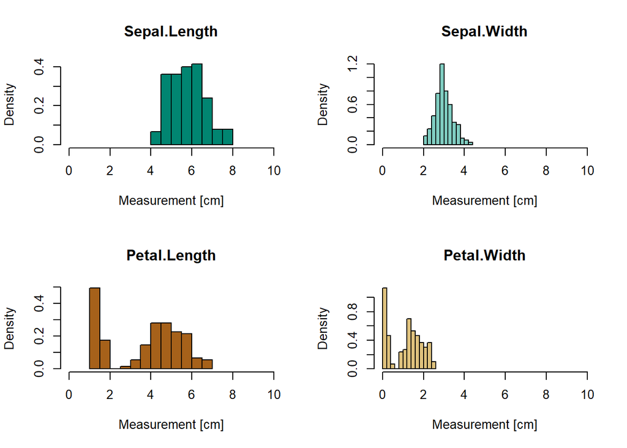

Figure 2.2: Histograms of the sepal and petal measurements.